# Portfolio

## Valence

The valence appears to barely have changed in the first three decades with a small drop to the last three decades.

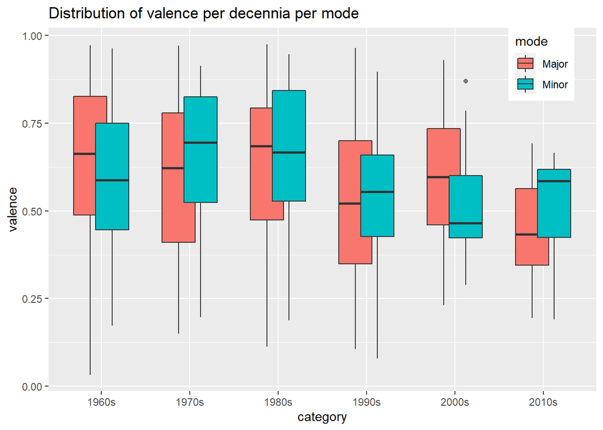

## Loudness & Energy

Comparing the energy related to loudness per decade show very similar clouds of data points. The 2000s and 2010s appear to lack songs in the lower ranges of loudness but this could be due to the fact that the playlists have less data points.

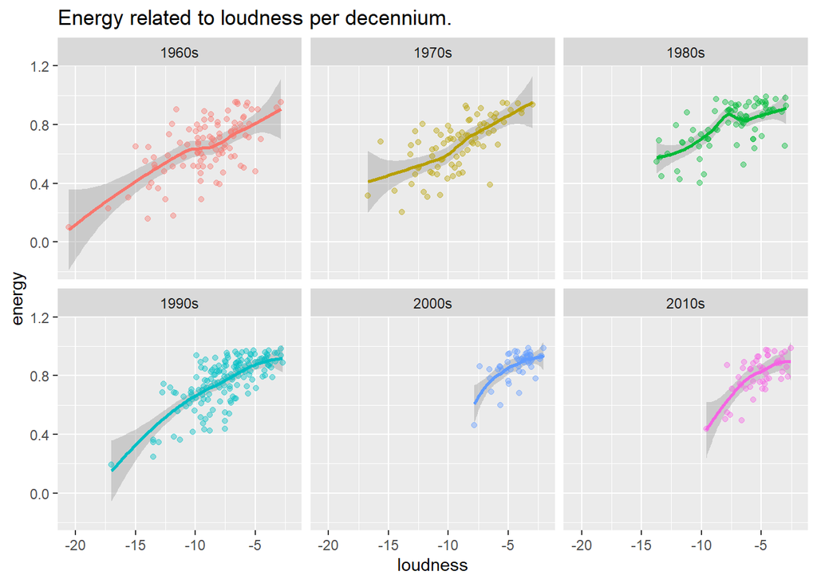